# Introduction to OceanSDM

### 3.4.2 Calculate the area of the predicted 2D map in each temporal bin

```r
## load the predicted 2D map of each quarter (derived by TB_sdm)
quarter_files<-c(
  Q1="F:/whaleshark_sdm/result_sdm/Q1/Ensemble/SUP/MAX_TSS/Rhincodon_typus.tif",
  Q2="F:/whaleshark_sdm/result_sdm/Q2/Ensemble/SUP/MAX_TSS/Rhincodon_typus.tif",
  Q3="F:/whaleshark_sdm/result_sdm/Q3/Ensemble/SUP/MAX_TSS/Rhincodon_typus.tif",
  Q4="F:/whaleshark_sdm/result_sdm/Q4/Ensemble/SUP/MAX_TSS/Rhincodon_typus.tif")
presence_tif <- lapply(quarter_files, raster::raster)
## Define Mollweide projection (equal-area, units: meters)
moll_crs <- "+proj=moll +lon_0=0 +x_0=0 +y_0=0 +datum=WGS84 +units=m +no_defs"
Temporal_bin <- c("Q1", "Q2", "Q3", "Q4")
## Store area (square kilometers)
area_km2 <- numeric(4)

for (i in 1:4) {
  r <- presence_tif[[i]]

  # Project to Mollweide (use nearest neighbour for binary data)
  r_proj <- projectRaster(r, crs = moll_crs, method = "ngb")

  # Extract cells with value 1
  cells_1 <- which(values(r_proj) == 1)

  # Cell area in square meters = xres * yres
  cell_area_m2 <- xres(r_proj) * yres(r_proj)

  # Total area in square kilometers
  total_area_km2 <- length(cells_1) * cell_area_m2 / 1e6

  area_km2[i] <- total_area_km2
}



## Create result data frame
volum_area <- data.frame(Temporal_bin = Temporal_bin, Area_km2 = area_km2/1e7)
print(volum_area)
```

```
#>   Temporal_bin Area_km2
#> 1           Q1 2.157078
#> 2           Q2 3.073917
#> 3           Q3 1.113728
#> 4           Q4 2.828210
```

```r
volum_area$Temporal_bin <- factor(volum_area$Temporal_bin, levels = c("Q1", "Q2", "Q3", "Q4"))
```

### 3.4.3 Plot the habitat volume and area into a single figure

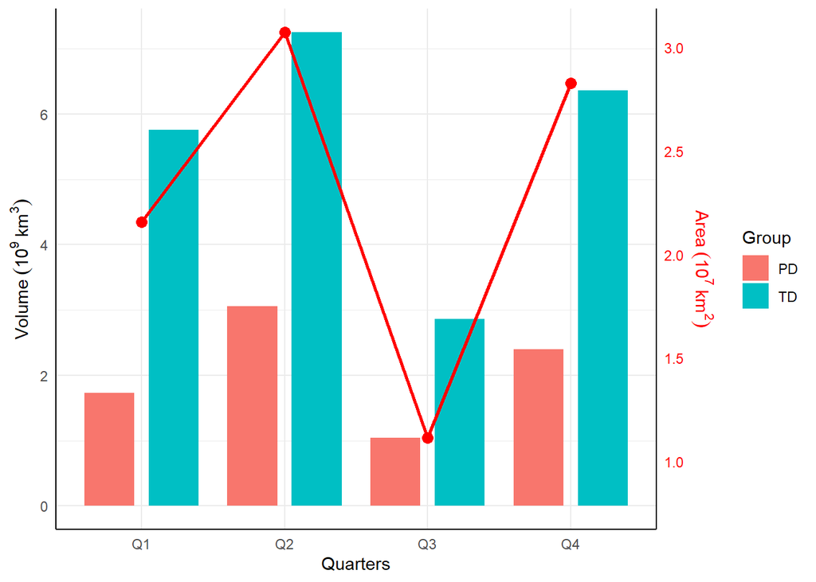

```r
## Create a barplot for the habitat volume estimated by TD and PD, respectively
p<-ggplot(volum, aes(x = Temporal_bin, y = Volume, fill = Group)) +
  geom_col(position = position_dodge(0.9), width = 0.7) +
  labs(x = "Quarters", y = expression(Volume~(10^9~km^3)), fill = "Group") +
  theme_minimal() +
  theme_classic()

## Combine volume and area plots

# Ensure Temporal_bin is an ordered factor (in the order Q1, Q2, Q3, Q4)

volum$Temporal_bin <- factor(volum$Temporal_bin, levels = c("Q1", "Q2", "Q3", "Q4"))

volum_area$Temporal_bin <- factor(volum_area$Temporal_bin, levels = c("Q1", "Q2", "Q3", "Q4"))

# Merge area data into the main dataset (for plotting)

volum_area_matched <- volum_area %>%
  right_join(volum %>% select(Temporal_bin) %>% distinct(), by = "Temporal_bin")

# Calculate the range of Volume (for automatic scaling of Area_km2)

vol_range <- range(volum$Volume, na.rm = TRUE)
area_range <- range(volum_area_matched$Area_km2, na.rm = TRUE)

# Scaling Factor: The numerical range mapping Area_km2 to Volume

# Mapping formula: area_scaled = (Area_km2 - area_min) / (area_max - area_min) * (vol_max - vol_min) + vol_min
area_min <- area_range[1]
area_max <- area_range[2]
vol_min <- vol_range[1]
vol_max <- vol_range[2]

# Avoid division by zero (if the area range is too small)

if (area_max == area_min) {
  scaling_factor <- 1
  offset <- 0
} else {
  scaling_factor <- (vol_max - vol_min) / (area_max - area_min)
  offset <- vol_min - scaling_factor * area_min
}

# Add a column for the scaled area

volum_area_matched$Area_scaled <- volum_area_matched$Area_km2 * scaling_factor + offset

# Draw a grouped bar chart

p <- ggplot(volum, aes(x = Temporal_bin, y = Volume, fill = Group)) +
  geom_col(position = position_dodge(0.9), width = 0.7) +

  # Add data for the second y-axis (line + points)

  geom_line(
    data = volum_area_matched,
    aes(x = Temporal_bin, y = Area_scaled, group = 1),
    color = "red", size = 1,
    inherit.aes = FALSE
  ) +
  geom_point(
    data = volum_area_matched,
    aes(x = Temporal_bin, y = Area_scaled),
    color = "red", size = 3,
    inherit.aes = FALSE
  ) +

  # Set the left y-axis (Volume) and the right y-axis (Area_km2)

  scale_y_continuous(
    name = expression(Volume~(10^9~km^3)),
    sec.axis = sec_axis(
      ~ (. - offset) / scaling_factor,
      name = expression(Area~(10^7~km^2))
    )
  ) +

  labs(x = "Quarters", fill = "Group") +
  theme_minimal() +
  theme(
    axis.line = element_line(),
    axis.title.y.right = element_text(color = "red"),
    axis.text.y.right = element_text(color = "red")
  )

p
```

```r
# ggsave(
#   filename = "F:/whaleshark_sdm/figures/TB_volume_area.tif",
#   plot = p,
#   device = "tiff",
#   dpi = 300,
#   compression = "lzw",
#   width = 6,
#   height = 6
# )
```

# References

Andrade, A. F. A. de, Velazco, S. J. E., & De Marco Júnior, P. (2020). ENMTML: An R package for a straightforward construction of complex ecological niche models. Environmental Modelling & Software, 125, 104615. https://doi.org/10.1016/j.envsoft.2019.104615

Andrzejaczek, S., Gleiss, A. C., Pattiaratchi, C. B., & Meekan, M. G. (2019). Patterns and drivers of vertical movements of the large fishes of the epipelagic. Reviews in Fish Biology and Fisheries, 29(2), 335–354. https://doi.org/10.1007/s11160-019-09555-1

Arrowsmith, L., Sequeira, A., Pattiaratchi, C., & Meekan, M. (2021). Water temperature is a key driver of horizontal and vertical movements of an ocean giant, the whale shark Rhincodon typus. Marine Ecology Progress Series, 679, 101–114. https://doi.org/10.3354/meps13899

Braun, C. D., Della Penna, A., Arostegui, M. C., Afonso, P., Berumen, M. L., Block, B. A., Brown, C. A., Fontes, J., Furtado, M., Gallagher, A. J., Gaube, P., Golet, W. J., Kneebone, J., Macena, B. C. L., Mucientes, G., Orbesen, E. S., Queiroz, N., Shea, B. D., Schratwieser, J., … Thorrold, S. R. (2023). Linking vertical movements of large pelagic predators with distribution patterns of biomass in the open ocean. Proceedings of the National Academy of Sciences, 120(47), e2306357120. https://doi.org/10.1073/pnas.2306357120

Coffey, D. M., Carlisle, A. B., Hazen, E. L., & Block, B. A. (2017). Oceanographic drivers of the vertical distribution of a highly migratory, endothermic shark. Scientific Reports, 7(1), 10434. https://doi.org/10.1038/s41598-017-11059-6

Dahms, C., & Killen, S. S. (2023). Temperature change effects on marine fish range shifts: A meta-analysis of ecological and methodological predictors. Global Change Biology, 29(16), 4459–4479. https://doi.org/10.1111/gcb.16770

Dobson, R., Challinor, A. J., Cheke, R. A., Jennings, S., Willis, S. G., & Dallimer, M. (2023). dynamicSDM: An R package for species geographical distribution and abundance modelling at high spatiotemporal resolution. Methods in Ecology and Evolution, 14(5), 1190–1199. https://doi.org/10.1111/2041-210X.14101

Hertz, P. E., Huey, R. B., & Stevenson. (1993). Evaluating Temperature Regulation by Field-Active Ectotherms: The Fallacy of the Inappropriate Question | The American Naturalist: Vol 142, No 5. The American Naturalist, 142(5). https://www.journals.uchicago.edu/doi/10.1086/285573

Naimi, B., & Araújo, M. B. (2016). sdm: A reproducible and extensible R platform for species distribution modelling. Ecography, 39(4), 368–375. https://doi.org/10.1111/ecog.01881

Owens, H. L., & Rahbek, C. (2023). voluModel: Modelling species distributions in three-dimensional space. Methods in Ecology and Evolution, 14(3), 841–847. https://doi.org/10.1111/2041-210X.14064

Valle, M., Ramírez-Romero, E., Ibaibarriaga, L., Citores, L., Fernandes-Salvador, J. A., & Chust, G. (2024). Pan-Atlantic 3D distribution model incorporating water column for commercial fish. Ecological Modelling, 490, 110632. https://doi.org/10.1016/j.ecolmodel.2024.110632